# Actividad Evaluable 2: Seminario Internacional en Herramientas y Técnicas de Detección de Ciberamenazas

Grupo CJLR

19 de marzo de 2026

# 1. Datos Elegantes + Análisis de Datos con Web Scrapping

## Pregunta 1

### 1. Descargar la página web de la URL indicada, y almacenarlo en un formato de R apto para ser tratado.

**Enunciado:**

El primer paso para realizar tareas de crawling y scraping es poder descargar los datos de la web. Para esto usaremos la capacidad de R y de sus librerías (httr y XML) para descargar webs y almacenarlas en variables que podamos convertir en un formato fácil de analizar (p.e. de HTML a XML)

**Respuesta:**

Primero, usando la librería `httr`, gestionamos la petición (`GET`) y aseguramos la respuesta exitosa mediante la variable `respuesta`.

```r
# Descarga de la página web
url_mediawiki <- "https://www.mediawiki.org/wiki/MediaWiki"
respuesta <- GET(url_mediawiki)
status_code(respuesta)
```

```
## [1] 200
```

Luego de asegurada la respuesta **200**, usamos las funciones `content` y `htmlParse` para crear un árbol DOM (Document Object Model) que optimiza las búsquedas posteriores mediante `XPath` sin saturar el servidor con nuevas peticiones.

```r
# Convertimos a formato XML para facilitar el análisis
contenido_html <- content(respuesta, as = "text")
parsed_item <- htmlParse(contenido_html, asText = TRUE)
```

Una vez almacenada la variable, podemos continuar con las demás actividades.

### 2. Analizar el contenido de la web, buscando el título de la página (que en HTML se etiqueta como “title”).

**Enunciado:**

En las cabeceras web encontramos información como el título, los ficheros de estilo visual, y meta-información como el nombre del autor de la página, una descripción de esta, el tipo de codificación de esta, o palabras clave que indican qué tipo de información contiene la página. Una vez descargada la página, y convertida a un formato analizable (como XML), buscaremos los elementos de tipo `“title”`. P.e. `“<title>Titulo de Página</title>”`.

**Respuesta:**

En la primera línea, `titulo_pagina <- xpathSApply(parsed_item, "//title", xmlValue)`, está extrayendo el título de la página web. Para ello, se utiliza `parsed_item`, que es el documento HTML previamente procesado y listo para ser analizado. La función `xpathSApply` busca dentro de ese documento todos los nodos que coinciden con la expresión `"//title"`, que indica que se debe encontrar la etiqueta `<title>` en cualquier parte del HTML. Una vez localizada, se aplica `xmlValue`, que se encarga de extraer el texto contenido dentro de esa etiqueta. El resultado final se guarda en la variable `titulo_pagina`.

```r
### Extracción del Título
titulo_pagina <- xpathSApply(parsed_item, "//title", xmlValue)
```

En la segunda línea, `n_caracteres <- nchar(titulo_pagina)`, realiza un análisis complementario del título obtenido. La función `nchar` sirve para contar el número de caracteres que tiene el texto almacenado en `titulo_pagina`. De esta forma, se obtiene la longitud del título de la página web, y el resultado se guarda en la variable `n_caracteres`.

```r
### Analisis Complementario
n_caracteres <- nchar(titulo_pagina)
```

De lo anterior,se ha extraído el título **MediaWiki**, cuya longitud es de **9** caracteres. La validación de su longitud asegura que el contenido sea legible y no presenta anomalìas estructurales.

### 3. Analizar el contenido de la web, buscando todos los enlaces (que en HTML se etiquetan como “a”), buscando el texto del enlace, así como la URL.

**Enunciado:**

Una vez descargada la página y convertida a formato XML, debemos analizar su contenido para localzar todos los enlaces HTML. Los enlaces se representan mediante la etiqueta `<a>`, donde el texto visible está dentro de la etiqueta y la dirección del enlace se encuentra en el atributo href. Usaremos funciones de la librería XML para extraer tanto el texto del enlace como su URL, y organizaremos los resultados en un data frame siguiendo el principio de **Datos Elegantes**, donde cada fila representa una observación.

**Respuesta:**

Primero, utilizamos la función `xpathSApply()` para buscar todos los nodos `<a>` dentro del documento HTML parseado, extrayendo por separado el texto visible del enlace y el atributo href, que contiene la URL.

```r
### 3. Extracción de información de hipervínculos
# Extraemos el texto que el usuario ve (anchor text)
textos_enlaces <- xpathSApply(parsed_item, "//a", xmlValue)

# Extraemos la dirección técnica (href)
hrefs_enlaces <- xpathSApply(parsed_item, "//a", xmlGetAttr, "href")
```

Luego consolidamos los resultamos en un **data frame**, donde cada fila corresponde a un enlace encontrado en la página.

```r
# Consolidamos en un Data Frame inicial (Tidy Data)
df_enlaces_raw <- data.frame(
  Texto = textos_enlaces,
  URL = hrefs_enlaces,
  stringsAsFactors = FALSE
)
```

Finalmente, mostramos los primeros registros para comprobar que la extracción se ha realizado correctamente. Al extraer ambos atributos por separado y unirlos en un data frame, cumplimos con el principio de “Datos Elegantes”, donde cada fila es una observación de un enlace encontrado en el HTML.

```r
# Visualización de los primeros registros
head(df_enlaces_raw)
```

```
##             Texto                                          URL
## 1 Jump to content                                 #bodyContent
## 2       Main page                              /wiki/MediaWiki
## 3   Get MediaWiki                               /wiki/Download
## 4  Get extensions /wiki/Special:MyLanguage/Category:Extensions
## 5       Tech blog              https://techblog.wikimedia.org/
## 6      Contribute   /wiki/Special:MyLanguage/How_to_contribute
```

### 4. Generar una tabla con cada enlace encontrado, indicando el texto que acompaña el enlace, y el número de veces que aparece un enlace con ese mismo objetivo.

**Enunciado:**

En este paso nos interesa reunir los datos obtenidos en el anterior paso. Tendremos que comprobar, para cada enlace, cuantas veces aparece.

**Respuesta:**

Para poder realizar esta actividad, es necesario primero crear un data frame `df_frecuencias`, el cual consiste en una copia de `df_enlaces_raw` creado anteriormente, en el que se ha ejecutado lo siguiente:

- Filtrado de NA, para eliminar enlaces nulos.
- Agrupación por enlace y por texto (para mantener una referencia legible del enlace).
- Sumarización.
- Ordenar frecuencia de forma descendente.

```r
### Consolidación y conteo de enlaces
df_frecuencias <- df_enlaces_raw %>%
  filter(!is.na(URL)) %>%  # Eliminación de enlaces nulos
  group_by(Texto,URL) %>%
  summarise(
    Frecuencia = n(), # Conteo de repeticiones por URL única
    .groups = "drop"
  ) %>%
  arrange(desc(Frecuencia))
```

Finalmente, se usa la función `datatable` para mostrar la tabla de frecuencias, donde la URL más encontrada es **#** apareciendo **7** veces.

```r
### Presentación de la tabla de frecuencias
datatable(df_frecuencias, colnames = c("URL", "Texto del enlace", "Frecuencia"))
```

|  | URL | Texto del enlace | Frecuencia |
| --- | --- | --- | --- |
| 1 |  | # | 7 |
| 2 | Donate | https://donate.wikimedia.org/?wmf_source=donate&amp;wmf_medium=sidebar&amp;wmf_campaign=www.mediawiki.org&amp;uselang=en | 2 |
| 3 | FAQ | /wiki/Special:MyLanguage/Manual:FAQ | 2 |
| 4 | Read | /wiki/MediaWiki | 2 |
| 5 | View history | /w/index.php?title=MediaWiki&amp;action=history | 2 |
| 6 | View source | /w/index.php?title=MediaWiki&amp;action=edit | 2 |
| 7 |  | /wiki/File:Wikimedia_Hackathon_2025_Group_photo_from_drone.jpg | 1 |
| 8 |  | https://www.mediawiki.org/ | 1 |
| 9 |  | https://www.wikimedia.org/ | 1 |
| 10 |  | /wiki/MediaWiki | 1 |

[output cut: 173 more lines]

### 5. Para cada enlace, seguirlo e indicar si está activo (podemos usar el código de status HTTP al hacer una petición a esa URL).

**Enunciado:**

En este paso podemos usar la función HEAD de la librería “httr”, que en vez de descargarse la página como haría GET, solo consultamos los atributos de la página o fichero destino.

**Respuesta:**

Primero, se crea la función `construir_url`, la cual permite estructurar los enlaces de la forma requerida. Luego, se crea otra función `verificar_status` para obtener el estado del enlace. Así mismo, `tryCatch` permite que el análisis sea resiliente ante fallos de red, timeouts o URLs malformadas. Los errores se capturan como valores NA.

```r
construir_url <- function(url, base = "https://www.mediawiki.org") {
  if (is.na(url) || url == "") return(NA)
  if (str_starts(url, "#")) {
    # Anchor → misma página
    return(base)
  }
  if (str_starts(url, "//")) {
    return(paste0("https:", url))
  }
  if (str_starts(url, "/")) {
    return(paste0(base, url))
  }
  if (str_starts(url, "http")) {
    return(url)
  }
  return(NA)
}

# Función de comprobación de salud de la URL
verificar_status <- function(url) {
  if (is.na(url)) return(NA)

  tryCatch({
    res <- HEAD(url, timeout(2), config(followlocation = FALSE))
    return(status_code(res))
  }, error = function(e) {
    return(NA)
  })
}
```

Ahora, se usarán las 2 funciones creadas para estructurar el data frame `df_verificacion` y mostrarlo mediante `datatable`.

```r
# Validación sobre una muestra para eficiencia del reporte
set.seed(123)
df_verificacion <- df_frecuencias %>%
  mutate(
    URL_final = sapply(URL, construir_url),
    Status_HTTP = sapply(URL_final, function(u) {
      Sys.sleep(1)
      verificar_status(u)
    }),
    Estado = case_when(
      is.na(Status_HTTP) ~ "Error desconocido",
      Status_HTTP >= 200 & Status_HTTP < 300 ~ "Activo (2xx)",
      Status_HTTP >= 300 & Status_HTTP < 400 ~ "Redirección (3xx)",
      Status_HTTP >= 400 & Status_HTTP < 500 ~ "Error cliente (4xx)",
      Status_HTTP >= 500 ~ "Error servidor (5xx)",

    )
  )
```

```r
datatable(df_verificacion)
```

|  | Texto | URL | Frecuencia | URL_final | Status_HTTP | Estado |
| --- | --- | --- | --- | --- | --- | --- |
| 1 |  | # | 7 | https://www.mediawiki.org | 301 | Redirección (3xx) |
| 2 | Donate | https://donate.wikimedia.org/?wmf_source=donate&amp;wmf_medium=sidebar&amp;wmf_campaign=www.mediawiki.org&amp;uselang=en | 2 | https://donate.wikimedia.org/?wmf_source=donate&amp;wmf_medium=sidebar&amp;wmf_campaign=www.mediawiki.org&amp;uselang=en | 302 | Redirección (3xx) |
| 3 | FAQ | /wiki/Special:MyLanguage/Manual:FAQ | 2 | https://www.mediawiki.org/wiki/Special:MyLanguage/Manual:FAQ | 200 | Activo (2xx) |
| 4 | Read | /wiki/MediaWiki | 2 | https://www.mediawiki.org/wiki/MediaWiki | 200 | Activo (2xx) |
| 5 | View history | /w/index.php?title=MediaWiki&amp;action=history | 2 | https://www.mediawiki.org/w/index.php?title=MediaWiki&amp;action=history | 200 | Activo (2xx) |
| 6 | View source | /w/index.php?title=MediaWiki&amp;action=edit | 2 | https://www.mediawiki.org/w/index.php?title=MediaWiki&amp;action=edit | 200 | Activo (2xx) |
| 7 |  | /wiki/File:Wikimedia_Hackathon_2025_Group_photo_from_drone.jpg | 1 | https://www.mediawiki.org/wiki/File:Wikimedia_Hackathon_2025_Group_photo_from_drone.jpg | 200 | Activo (2xx) |
| 8 |  | https://www.mediawiki.org/ | 1 | https://www.mediawiki.org/ | 301 | Redirección (3xx) |
| 9 |  | https://www.wikimedia.org/ | 1 | https://www.wikimedia.org/ | 200 | Activo (2xx) |
| 10 |  | /wiki/MediaWiki | 1 | https://www.mediawiki.org/wiki/MediaWiki | 200 | Activo (2xx) |

[output cut: 173 more lines]

## Pregunta 2

A continuación, se presenta una infografía compuesta por tres visualizaciones críticas que resumen la estructura y salud del portal analizado. El objetivo es transformar los datos técnicos en información visual estratégica para la toma de decisiones.

### 1.Un histograma con la frecuencia de aparición de los enlaces, pero separado por URLs absolutas (con “http…”) y URLs relativas.

**Enunciado:**

A partir de los enlaces obtenidos en el apartado anterior debemos analizar la frecuencia con la que aparecen en la página web y distinguir entre URLs absolutas y URLs relativas. Para ello, clasificaremos cada enlace según su tipo de ruta y generaremos un histograma que permita visualizar la distribución de frecuencias.

**Respuesta:**

Primero, utilizamos la tabla de frecuencia obtenida previamente y clasificamos cada URL según su tipo. Consideramos como URL absoluta aquellas que comienzan con “http”, mientras que el resto se considera URLs relativas, ya que corresponden a enlaces internos del site.

```r
# Clasificación de enlaces por tipo de ruta
df_graficos <- df_verificacion %>%
  mutate(Tipo = ifelse(str_starts(URL, "http"), "Absoluta", "Relativa"))
```

Una vez clasificados los enlaces, generamos un histograma que muestre la distribución de la frecuencia de aparición de los enlaces, separando los resultados según el tipo de URL.

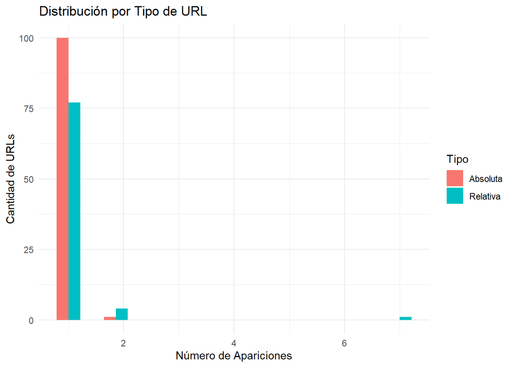

```r
# Generación del histograma
p1 <- ggplot(df_graficos, aes(x = Frecuencia, fill = Tipo)) +
  geom_histogram(bins = 15, position = "dodge", na.rm = TRUE) +
  labs(title = "Distribución por Tipo de URL",
       x = "Número de Apariciones",
       y = "Cantidad de URLs") +
  theme_minimal()

p1
```

Este gráfico permite observar la distribución de la frecuencia de aparición de los enlaces, diferenciando entre enlaces internos (relativos) y externos (absolutos).

Se aprecia que la mayoría de las URLs presentan una frecuencia baja, lo que indica que la mayor parte de los enlaces aparecen de forma puntual dentro del sitio. Además, la presencia de valores de frecuencia más elevados puede asociarse a elementos estructurales del sitio, como menús de navegación o enlaces recurrentes.

### 2. Un gráfico de barras indicando la suma de enlaces que apuntan a otros dominios o servicios (distinto a https://www.mediawiki.org en el caso de ejemplo) vs. la suma de los otros enlaces.

**Enunciado:**

Aquí quere hmos distinguir enlaces que apuntan a mediawiki versus el resto. Sabemos que las URLs relativas ya apuntan dentro, por lo tanto hay que analizar las URLs absolutas y comprobar que apunten a `https://www.mediawiki.org`.

**Respuesta:**

Ya que requieren la suma de enlaces que apuntan al dominio oficial de MediaWiki frente a dominios externos o servicios ajenos, primero se procede con la identificación de los mismos, partiendo del `df_graficos`, detectando la pertenencia.

```r
# Identificación de pertenencia al dominio
df_graficos <- df_graficos %>%
  mutate(Destino = ifelse(Tipo == "Relativa" | str_detect(URL, "https://www.mediawiki.org"), "MediaWiki", "Externo"))
```

Luego ello, generamos el resumen_barras, el cual tiene agrupado los Destino y se aplica el parámetro na.rm = TRUE para asegurar que los valores desconocidos no afecten el cómputo total de la infraestructura.

```r
# Agregación de datos aplicando na.rm = TRUE
resumen_barras <- df_graficos %>%
  group_by(Destino) %>%
  summarise(Total_Suma = sum(Frecuencia, na.rm = TRUE))
```

Este gráfico es fundamental para distinguir la dependencia de servicios externos frente al control del contenido propio.

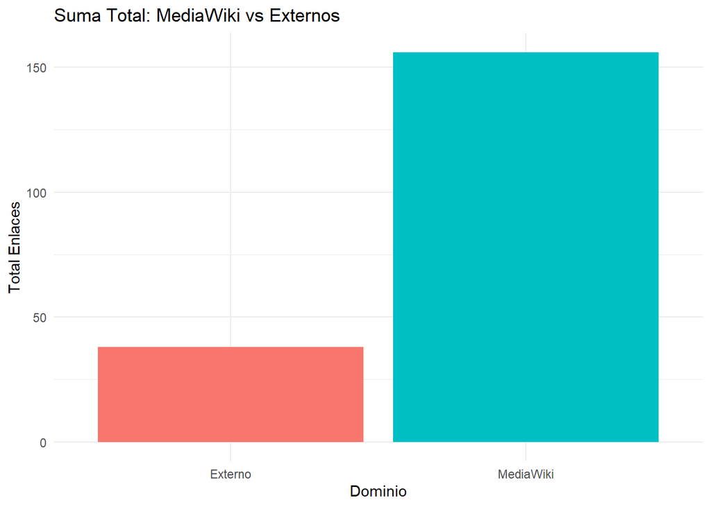

```r
# Generación del gráfico de barras
p2 <- ggplot(resumen_barras, aes(x = Destino, y = Total_Suma, fill = Destino)) +
  geom_bar(stat = "identity", na.rm = TRUE) +
  labs(title = "Suma Total: MediaWiki vs Externos",
       x = "Dominio",
       y = "Total Enlaces") +
  theme_minimal() +
  guides(fill = "none")

p2
```

### 3. Un gráfico de tarta (pie chart) indicando los porcentajes de Status de nuestro análisis.

**Enunciado:**

Por ejemplo, si hay 6 enlaces con status “200” y 4 enlaces con status “404”, la tarta mostrará un 60% con la etiqueta “200” y un 40% con la etiqueta “404”. Este gráfico lo uniremos a los anteriores. El objetivo final es obtener una imagen que recopile los gráficos generados.

**Resultado:**

La tarta ofrece una visión ejecutiva e inmediata de la salud del sitio. Los porcentajes calculados permiten identificar rápidamente la tasa de enlaces activos (Status 200) frente a posibles enlaces rotos o errores, facilitando una auditoría de integridad rápida. Para ello, vamos a preparar 3 segmentos de codigo.

Primero, se crea el data frame `data_pie` a partir de `df_verificacion`. Dentro, contamos la columna `Estado` y agregamos la columna `Porcentaje`.

```r
# Preparación de datos porcentuales
data_pie <- df_verificacion %>%
  filter(!is.na(Estado)) %>%
  count(Estado) %>%
  mutate(Porcentaje = n / sum(n) * 100)
```

Posterior a ello, estructuramos el gráfico, de manera que sea lo más amigable posible.

```r
# Generación del gráfico de tarta
p3 <- ggplot(data_pie, aes(x = "", y = Porcentaje, fill = Estado)) +
  geom_bar(stat = "identity", width = 1) +
  coord_polar("y", start = 0) +
  theme_void() +
  labs(
    title = "Disponibilidad Operativa (%)",
    fill  = "Estado HTTP"
  ) +
  geom_text(aes(label = paste0(round(Porcentaje, digits = 1), "%")),
            position = position_stack(vjust = 0.5))
```

Por último, cambiamos los colores para que sea mejor entendible.

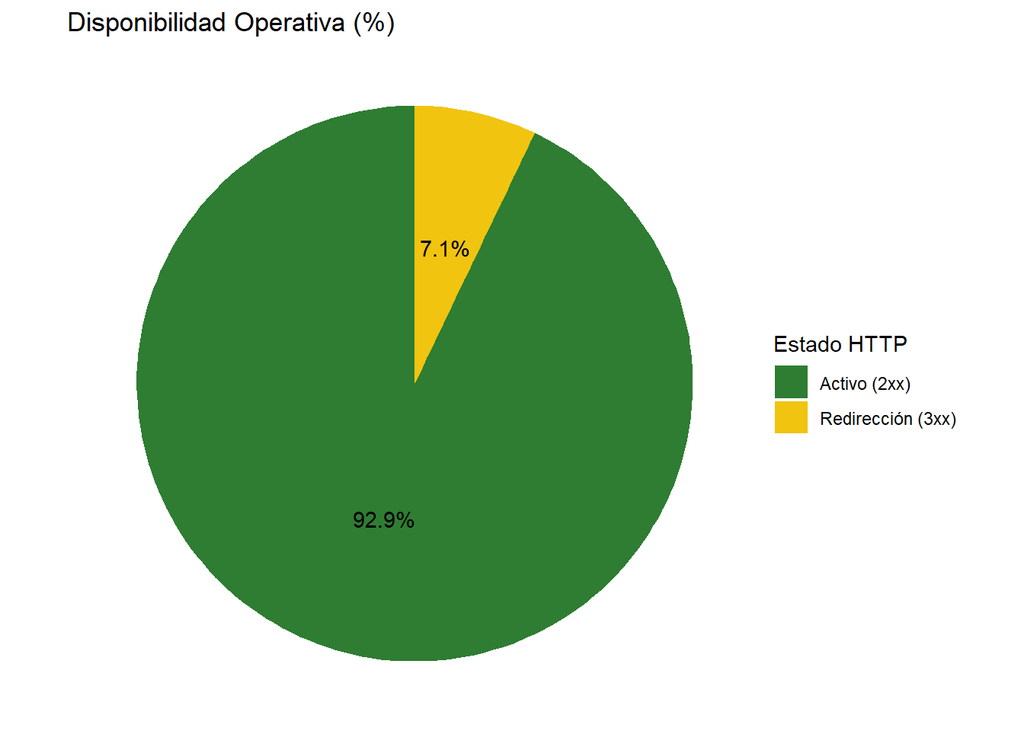

```r
p3 <- p3 +
  scale_fill_manual(values = c(
    "Activo (2xx)" = "#2E7D32",
    "Redirección (3xx)" = "#F1C40F",
    "Error cliente (4xx)" = "#FF8A65",
    "Error servidor (5xx)" = "#B71C1C",
    "Error desconocido" = "#757575"
  ))

p3
```